# Tarea 1 Chapulin de milpa

Mendoza Cruz Erick Simon

8 de marzo de 2021

Valor de uso: El chapulín es un producto agropecuario que al menos en la gastronomía mexicana tradicional representa un gran patrimonio cultural, por su amplia versatilidad en platillos y recientemente por el conocimiento de la gran aportación nutrimental que tiene forma parte de la cocina mexicana.

Valor de cambio: Nuestro país puede convertirse en uno de los principales productores de insectos en el mundo. Y en ese sentido, México debe estar a la vanguardia de la revolución del insecto comestible, en una industria que hoy tiene un valor estimado en el mercado global de 607.5 millones de dólares, que para 2025 se cree será el doble. El clima cálido y húmedo de México es propicio para la cría de insectos, pero su industria va a la zaga de EUA, Canadá, Países Bajos, Bélgica, Francia, Reino Unido, Dinamarca, Finlandia y muchos países asiáticos, en especial Tailandia, líder mundial en la industria.

Valor: Por ejemplo, los chapulines y las mariposas son ricos en tiamina, y los los gusanos de maguey (rojos y blancos), lo son en grasas; la grana cochinilla cuenta con un pigmento (ácido carmínico) que se utiliza en la industria alimentaria, farmacéutica, dulcera, refresquera y láctea, entre otras. En México se industrializa la comida entomófaga en Oaxaca, Hidalgo, Puebla, Estado de México, Ciudad de México y Querétaro, entre otras entidades.

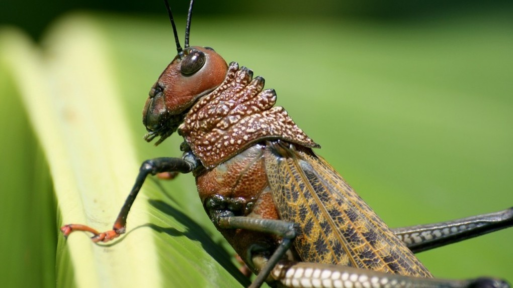

wsimag.com/

## Bibliografía

1. https://www.dgcs.unam.mx/boletin/bdboletin/2020_236.html
2. https://www.gaceta.unam.mx/el-chapulin-de-milpa-mejor-que-la-carne/
3. https://www.jornada.com.mx/2006/01/15/index.php?section=economia&article=025n1eco